# Association analysis

Nomei Nicole Piga

21 April, 2023

```r
#library reticulate to be able to add chunks in another language
library(reticulate)
#To run this .rmd file in a terminal being in the project folder:
#export PATH=${PATH}:/cm/shared/apps/R/deps/rstudio/bin/pandoc
#file="./report/Association_analysis.Rmd"
#module unload R/4.2.1
#module load R/4.1.0
#Rscript -e 'rmarkdown::render("'$file'")'
```

# Rationale

Genome-wide association analysis (GWAS) 7,681 severe asthma cases and 38,405 controls in European ancestry UK Biobabank participants. For details of the phenotype definition and case/control dataset, lease see ‘Phenotype Definition’ and ‘GWAS –> Case/Control and descriptive analysis’ sections.

# Analysis

## Code

Code: src/plink_QC_eur.sh

```r
#!/bin/bash

#PBS -N plinkQC
#PBS -j oe
#PBS -o log
#PBS -l walltime=1:0:0
#PBS -l nodes=1:ppn=2
#PBS -l vmem=30gb
#PBS -W umask=022


PATH_DATA="/home/n/nnp5/PhD/PhD_project/REGENIE_assoc/data"
OUT_DIR="/home/n/nnp5/PhD/PhD_project/REGENIE_assoc/output"
geno_dir="/data/ukb/genotyped"
scratch_dir="/scratch/gen1/nnp5/REGENIE_assoc/tmp_data"

#to create list of eur ids
awk {'print $1, $2'} ${PATH_DATA}/demo_EUR_pheno_cov.txt | tail -n +2 > ${PATH_DATA}/ukb_eur_ids

#cp from /rfs to my home the .fam
#cp /rfs/TobinGroup/data/UKBiobank/application_56607/ukb56607_cal_chr1_v2_s488239.fam ${PATH_DATA}/

#rm ${PATH_DATA}/list_plink_files
#for chr in {2..22}
#do echo "${geno_dir}/ukb_cal_chr${chr}_v2.bed ${geno_dir}/ukb_cal_chr${chr}_v2.bim ${PATH_DATA}/ukb56607_cal_chr1_v2_s488239.fam" >> ${PATH_DATA}/list_plink_files
#done

#module load plink
#plink --bed ${geno_dir}/ukb_cal_chr1_v2.bed \
#   --bim ${geno_dir}/ukb_cal_chr1_v2.bim \
#   --fam ${PATH_DATA}/ukb56607_cal_chr1_v2_s488239.fam \
#   --merge-list ${PATH_DATA}/list_plink_files \
#   --make-bed --out ${scratch_dir}/ukb_cal_allchr_v2 &&

#awk '{print $1, $1}' /home/n/nnp5/PhD/PhD_project/UKBiobank_datafields/data/Eid_withdrawn_participants_upFeb2022.txt \
#    > ${PATH_DATA}/ukb_withdrawns_ids &&

module load plink2
plink2 --bfile ${scratch_dir}/ukb_cal_allchr_v2 \
    --maf 0.01 --mac 100 --geno 0.1 --hwe 1e-15 \
    --keep ${PATH_DATA}/ukb_eur_ids \
    --remove ${PATH_DATA}/ukb_withdrawns_ids \
    --mind 0.1 \
    --write-snplist --write-samples --no-id-header \
    --out ${scratch_dir}/ukb_cal_allchr_eur_qc &&

cp ${scratch_dir}/ukb_cal_allchr_eur_qc.id ${PATH_DATA}
```

Code: src/broad_phenotype/run_regenie_step1.sh

```r
#!/bin/bash

#PBS -N regenie1
#PBS -j oe
#PBS -o log_regenie_step1
#PBS -l walltime=15:0:0
#PBS -l nodes=1:ppn=4
#PBS -l vmem=50gb
#PBS -W umask=022

PATH_DATA="/data/gen1/UKBiobank_500K/severe_asthma/Noemi_PhD/data/"
OUT_DIR="/home/n/nnp5/PhD/PhD_project/REGENIE_assoc/output"
scratch_dir="/scratch/gen1/nnp5/REGENIE_assoc/tmp_data"
pheno="broad_pheno_1_5_ratio"
test_type="recessive" #additive, this variable is NULL (default) or dominant or recessive

module load regenie
regenie \
  --step 1 \
  --bed ${scratch_dir}/ukb_cal_allchr_v2 \
  --extract ${scratch_dir}/ukb_cal_allchr_eur_qc.snplist \
  --keep ${scratch_dir}/ukb_cal_allchr_eur_qc.id \
  --phenoFile ${PATH_DATA}/demo_EUR_pheno_cov_broadasthma.txt \
  --phenoCol ${pheno} \
  --covarFile ${PATH_DATA}/demo_EUR_pheno_cov_broadasthma.txt \
  --covarColList age_at_recruitment,age2,PC1,PC2,PC3,PC4,PC5,PC6,PC7,PC8,PC9,PC10,genetic_sex \
  --bt \
  --bsize 1000 \
  --loocv \
  --threads 4 \
  --gz \
  --test ${test_type} \
  --out ${OUT_DIR}/${pheno}.${test_type}regenie.step1
```

Code: src/broad_phenotype/run_regenie_step2.sh

```r
#!/bin/bash

#PBS -N regenie2
#PBS -j oe
#PBS -o log_regenie_step2
#PBS -l walltime=13:0:0
#PBS -l nodes=1:ppn=4
#PBS -l vmem=64gb
#PBS -W umask=022

chr=$PBS_ARRAYID
PATH_DATA="/data/gen1/UKBiobank_500K/severe_asthma/Noemi_PhD/data/"
OUT_DIR="/home/n/nnp5/PhD/PhD_project/REGENIE_assoc/output"
sample_DIR="/data/gen1/UKBiobank_500K/severe_asthma/data"
scratch_DIR="/scratch/gen1/nnp5/REGENIE_assoc/tmp_data"
pheno="broad_pheno_1_5_ratio"

#run as: qsub -t 1-22 src/broad_phenotype/run_regenie_step2.sh

cd src/

#if additive (default, so no need to explicit it):
module load regenie
regenie \
  --step 2 \
  --bgen /data/ukb/imputed_v3/ukb_imp_chr${chr}_v3.bgen \
  --ref-first \
  --sample ${sample_DIR}/ukbiobank_app56607_for_regenie.sample \
  --keep ${scratch_DIR}/ukb_cal_allchr_eur_qc.id \
  --phenoFile ${PATH_DATA}/demo_EUR_pheno_cov_broadasthma.txt \
  --phenoCol ${pheno} \
  --covarFile ${PATH_DATA}/demo_EUR_pheno_cov_broadasthma.txt \
  --covarColList age_at_recruitment,age2,PC1,PC2,PC3,PC4,PC5,PC6,PC7,PC8,PC9,PC10,genetic_sex \
  --bt \
  --gz \
  --threads 4 \
  --minMAC 10 \
  --minINFO 0.3 \
  --firth --approx --pThresh 0.01 \
  --pred ${OUT_DIR}/${pheno}.regenie.step1_pred.list \
  --bsize 1000 \
  --out ${OUT_DIR}/${pheno}.${chr}.regenie.step2


#if recessive or dominant:
#test_type="additive" #additive, this variable is NULL (default) or dominant
#module load regenie
#regenie \
#  --step 2 \
#  --bgen /data/ukb/imputed_v3/ukb_imp_chr${chr}_v3.bgen \
#  --ref-first \
#  --sample ${sample_DIR}/ukbiobank_app56607_for_regenie.sample \
#  --keep ${scratch_DIR}/ukb_cal_allchr_eur_qc.id \
#  --phenoFile ${PATH_DATA}/demo_EUR_pheno_cov_broadasthma.txt \
#  --phenoCol ${pheno} \
#  --covarFile ${PATH_DATA}/demo_EUR_pheno_cov_broadasthma.txt \
#  --covarColList age_at_recruitment,age2,PC1,PC2,PC3,PC4,PC5,PC6,PC7,PC8,PC9,PC10,genetic_sex \
#  --bt \
#  --gz \
#  --threads 4 \
#  --minMAC 10 \
#  --minINFO 0.3 \
#  --firth --approx --pThresh 0.01 \
#  --pred ${OUT_DIR}/${pheno}.${test_type}regenie.step1_pred.list \
#  --bsize 1000 \
#  --test ${test_type} \
#  --out ${OUT_DIR}/${pheno}.${chr}.${test_type}regenie.step2
```

Code: src/broad_phenotype/postGWAS_analyses.sh

```r
#!/bin/bash

#PBS -N post_gwas_asthma_broadpheno
#PBS -j oe
#PBS -o post_gwas_asthma_broadpheno
#PBS -l walltime=3:0:0
#PBS -l vmem=50gb
#PBS -l nodes=1:ppn=1
#PBS -d .
#PBS -W umask=022


#Set variables:
PATH_OUT="/home/n/nnp5/PhD/PhD_project/REGENIE_assoc/output"
PHENO="broad_pheno_1_5_ratio"

#PHENO to change into:
#"broad_pheno_1_5_ratio"
#"broad_pheno_female"
#"broad_pheno_male"
#"broad_pheno_adultonset"
#"broad_pheno_childhoodonset"
#"broad_pheno_1_5_ratio"
test_type="recessive" #additive: NULL. use ONLY  this variable only with dominant or recessive test
test_type_underscore="recessive_" #additive: NULL. use ONLY  this variable only with dominant or recessive test

#N of individuals, to change:
tot_n=46086
#tot_n for broad pheno (additive recessive and dominant): 46086
#tot_n for broad pheno female: 29646
#tot_n for broad pheno male: 16440
#tot_n for broad pheno adultonset: 42919
#tot_n for broad pheno childhoodonset: 39944

#mkdir ${PATH_OUT}/allchr
GWAS="/home/n/nnp5/PhD/PhD_project/REGENIE_assoc/output/allchr"


#merge all assoc file:
#zcat ${PATH_OUT}/${PHENO}.1.${test_type}regenie.step2_${PHENO}.regenie.gz | tail -n +2 | \
#     awk -F " " '{print $1, $2, $3, $4, $5, $6, $7, $8, $9, $10, $11, $12, $13}' \
#    > ${GWAS}/${PHENO}_${test_type}allchr.assoc.txt

#for i in {2..22}
#    do zcat ${PATH_OUT}/${PHENO}.${i}.${test_type}regenie.step2_${PHENO}.regenie.gz | \
#    tail -n +2 | awk -F " " '{print $1, $2, $3, $4, $5, $6, $7, $8, $9, $10, $11, $12, $13}' \
#    >> ${GWAS}/${PHENO}_${test_type}allchr.assoc.txt
#done

#gzip ${GWAS}/${PHENO}_${test_type}allchr.assoc.txt

#create input ldsc file both for all vars and maf >= 0.01.
#module unload R/4.2.1
#module load R/4.1.0
#chmod o+x src/create_input_munge_summary_stats.R
#dos2unix src/create_input_munge_summary_stats.R
#Rscript src/create_input_munge_summary_stats.R \
#    ${GWAS}/${PHENO}_${test_type}allchr.assoc.txt.gz \
#    ${PHENO}_${test_type}

#LDSC interactively.
#The results are the same for set with all vars and fitlered maf 0.01., because LDSC uses only vars > 0.01. So run
#on the filtered set
#cd /home/n/nnp5/software/ldsc
#conda activate ldsc

PHENO="maf001_broad_pheno_1_5_ratio"
#"maf001_broad_pheno_1_5_ratio" for additive, recessive, dominant models
#"maf001_broad_pheno_female"
#"maf001_broad_pheno_male"
#"maf001_broad_pheno_adultonset"
#"maf001_broad_pheno_childhoodonset"

#awk '{print $1, $2, $3, $4, $5, $6, $7, $8, $9}' ${PATH_OUT}/${PHENO}_${test_type_underscore}betase_input_mungestat \
#    > ${PATH_OUT}/${PHENO}_${test_type_underscore}betase_input_mungestat_clean

#interactively:
#/home/n/nnp5/software/ldsc/munge_sumstats.py \
#--sumstats ${PATH_OUT}/${PHENO}_${test_type_underscore}betase_input_mungestat_clean \
#--N ${tot_n}   \
#--out ${PATH_OUT}/${PHENO}_${test_type_underscore}allchr_step2_regenie \
#--merge-alleles /data/gen1/UKBiobank/Smoking/Meta_Analysis_AWI_UGR_UKBAFR/files/w_hm3.snplist \
#--chunksize 500000

#/home/n/nnp5/software/ldsc/ldsc.py \
#--h2 ${PATH_OUT}/${PHENO}_${test_type_underscore}allchr_step2_regenie.sumstats.gz \
#--ref-ld-chr /data/gen1/reference/ldsc/eur_w_ld_chr/ \
#--w-ld-chr /data/gen1/reference/ldsc/eur_w_ld_chr/ \
#--out ${PATH_OUT}/${PHENO}_${test_type_underscore}allchr_step2_regenie_h2

#conda deactivate
#cd /home/n/nnp5/PhD/PhD_project/REGENIE_assoc/

#Plots:
ldsc_intercept=1.00
#broad pheno:'1.02'
#broad pheno female:'1.02'
#broad pheno adultonset:'1.00'
#broad pheno male:'1.04'
#broad pheno childhoodonset:'1.02'
#broad pheno dominant:'1.01'
#broad pheno recessive:'1.00'

#run Manhattan, qqplot, lambda for vars with maf >= 0.01:
module unload R/4.2.1
module load R/4.1.0
chmod o+x src/REGENIE_plots.R
dos2unix src/REGENIE_plots.R
Rscript src/REGENIE_plots.R \
    ${PATH_OUT}/${PHENO}_${test_type_underscore}betase_input_mungestat \
    ${PHENO}_${test_type} \
    ${ldsc_intercept}

#extract only genome-wide significant variants:
#awk -F "\t" '$9 <= 0.00000005 {print $0}' ${PATH_OUT}/${PHENO}_${test_type_underscore}betase_input_mungestat \
#    > ${PATH_OUT}/${PHENO}_${test_type_underscore}genomewide_signif

#Sentinel selection:
#module unload R/4.2.1
#module load R/4.1.0
#chmod o+x src/sentinel_selection.R
#dos2unix src/sentinel_selection.R
#Rscript src/sentinel_selection.R \
#    ${PATH_OUT}/${PHENO}_${test_type_underscore}betase_input_mungestat \
#    ${PHENO} \
#    500000 \
#    0.00000005 \
#    ${test_type}

#create OddsRatio and direction of effect using Create_oddsratio.R
#Rscript src/broad_phenotype/Create_oddsratio.R ${PATH_OUT}/${PHENO}${test_type}_sentinel_variants.txt ${PATH_OUT}/${PHENO}_${test_type_underscore}sentinel_variants_OR.txt
```

Code: src/create_input_munge_summary_stats.R

```r
#!/usr/bin/env Rscript

library(data.table)
library(tidyverse)

args = commandArgs(trailingOnly=TRUE)
df_file <- args[1]
pheno <- as.character(args[2])

df <- fread(df_file,header=F)

#CHROM GENPOS ID ALLELE0 ALLELE1 A1FREQ INFO N TEST BETA SE CHISQ LOG10P
#REGENIE: reference allele (allele 0), alternative allele (allele 1)
#REGENIE:  estimated effect sizes (for allele 1 on the original scale)

colnames(df) <- c("CHROM", "GENPOS", "ID", "ALLELE0", "ALLELE1", "A1FREQ", "INFO", "N","TEST", "BETA", "SE", "CHISQ", "LOG10P")
dfclean <- df %>% select(CHROM,ID,GENPOS,ALLELE1,ALLELE0,A1FREQ,LOG10P,BETA,SE)

dfclean$pval <- 10^(-dfclean$LOG10P)

#select column in order:
dfclean <- dfclean %>% select(ID,CHROM,GENPOS,ALLELE1,ALLELE0,BETA,SE,A1FREQ,pval)

#rename columns :
colnames(dfclean) <- c("snpid", "b37chr", "bp", "a1", "a2", "LOG_ODDS", "se", "eaf", "pval")
#save gwas all chr results:

#write.table(dfclean,paste0("output/",pheno,"_betase_input_mungestat"),quote=FALSE,sep="\t",row.names=FALSE)


#make sure eaf column is numeric:
dfclean$eaf <- as.numeric(dfclean$eaf)

#create MAF columns and filtered out for MAF >= 0.01:
dfclean <- dfclean %>% mutate(MAF = ifelse(dfclean$eaf <= 0.5, dfclean$eaf, 1 - dfclean$eaf))
dfclean_MAF001 <- dfclean %>% filter(MAF >= 0.01)

#save gaws results for variants with MAF >= 0.01:
write.table(dfclean_MAF001,paste0("output/maf001_",pheno,"_betase_input_mungestat"),quote=FALSE,sep="\t",row.names=FALSE)
```

Code: src/REGENIE_plots.R

```r
#!/usr/bin/env Rscript
library(qqman) #qq plot and manhattan plot
library(ggplot2)
library(data.table)
library(grid)
library(tidyverse)
#call the plot_functions.R for QQ-plot,Manhattan and lambda:
source("src/plot_functions.R")

args = commandArgs(TRUE)


#inputfile:
input_file = args[1] #input mungestat file
pheno = args[2]
ldsc_intercept = as.numeric(args[3])
#input
meta <- fread(input_file, header=T, fill=T)

title_plot <- paste0("GWAS_",pheno)


#QQ plot with qqman package: one genome-wide for each test-statistic p-val:
#plot.qqplot(pval_vec = meta$pval, title= title_plot)


#Manhattan plot:
# require these columns: rs,chr,ps,pval
df <- meta %>% select(snpid,b37chr,bp,pval)
colnames(df) <- c("rs","chr","ps","pval")
df$chr <- as.numeric(df$chr)
df$ps <- as.numeric(df$ps)
plot.Manha(df, title = title_plot)


#Lambda (inflation of genetic factor) from pval:
#lambda <- lambda_func(meta$pval, title = title_plot)

if (ldsc_intercept >= 1.05) {
    print("Correct for lambda >= 1.05")
    meta$se_gc <- meta$SE * sqrt(as.numeric(ldsc_intercept))
    z <- -abs(meta$BETA/meta$se_gc)
    meta$pval_gc <- 2*pnorm(z)
    title_plot <- paste0("gc_GWAS_",pheno)
    #QQ plot:
    plot.qqplot(pval_vec = meta$pval_gc, title= title_plot)
    #Manhattan plot:
    df <- meta %>% select(ID,CHROM,GENPOS,pval_gc)
    colnames(df) <- c("rs","chr","ps","pval")
    df$chr <- as.numeric(df$chr)
    df$ps <- as.numeric(df$ps)
    plot.Manha(df, title = title_plot)
}
```

Code: src/plot_functions.R

```r
#Plot inflation plot with qqman package and qq() function.
plot.qqplot <- function(pval_vec,title){
           filename = paste0("output/Q-Q_plot_",title,".png")
           plot_title = paste0("Q-Q plot ",title)
           png(filename, width = 480, height = 480, units = "px", pointsize = 12, bg = "white")
               print(qq(pval_vec, main = plot_title, xlim = c(0,27), ylim = c(0,27), cex.axis = 1, cex = 1, las = 1)) #function from qqman library
               dev.off()
}

# Create a Manhattan plot from a data frame containing the results of
# a GEMMA association analysis.
plot.Manha <- function (dataset,test_type,title) {
          colnames(dataset) <- c("SNP","CHR","BP","P") #the Manhattan function needs this format
              filename <- paste0("output/Manhattan_plot_",title,".png")
              plot_title = paste0("Manhattan plot ",title)
          png(filename, width = 3200, height = 550, units = "px", pointsize = 12, bg = "white")
          manhattan(dataset, main = title, col = c("lightblue","blue3"), chrlabs = as.character(c(1:22)), ylim=c(0,25),
          cex = 1.5, cex.axis = 1.5, suggestiveline = F, genomewideline = F, cex.lab = 1.5)
          #function from qqman library
          abline(h=-log10(0.00000005),lty="dashed",col="black")
          abline(h=-log10(0.000005),lty="solid",col="black")
          dev.off()
}





#Estimate lambda using pval:
lambda_func <- function(pval,title){
        filename <- paste0("output/lambda_",title,".txt")
        pval <- qnorm(pval/2)
        lambda_frompval = round(median(pval^2,na.rm=T)/qchisq(0.5,df=1),2)
        write.table(lambda_frompval,filename,col.names="lambda",row.names=F)
        return
        lambda_frompval
}














# Create a simple Manhattan plot from a data frame containing the
# results of a GEMMA association analysis, in which p-values are
# plotted against base-pair positions (in Mb).
plot.region.pvalues <- function (gwscan, size = 1) {

  # Convert the p-values to the -log10 scale.
  gwscan <- transform(gwscan,p_lrt = -log10(p_lrt))

  # Convert the positions to the Megabase (Mb) scale.
  gwscan <- transform(gwscan,ps = ps/1e6)

  # Create a Manhattan plot.
  return(ggplot(gwscan,aes(x = ps,y = p_lrt)) +
         geom_point(color = "darkblue",size = size,shape = 20) +
         labs(x = "base-pair position (Mb)",y = "-log10 p-value") +
         theme_cowplot(font_size = 10) +
         theme(axis.line = element_blank()))
}
```

## Genotype and Imputation data

UK Biobank individuals were genotyped using the UK Biobank Axiom Array including 825,927 variants53. Imputed data for ~93M autosomal variants53 were obtained using a combined reference panel inclusive of the Haplotype Reference Consortium panel7, the UK10K8 and 1000GP Phase 39.

## Power calculation

I used the GAS Power Calculator, a free accessible online tool to compute statistical power for one-stage genetic association analysis [3]. The parameters used were (Fig 1): sample size (7,681 cases; 38405 control); significance level (5e-8); multiplicative disease model (equivalent to additive model for this software); prevalence of disease as the proportion of asthmatic individuals taking high intensity treatments as a proxy for our case definition, which is estimated to be 24% of the asthma population [4] (24% of 12% as prevalence of all asthma in UK population, thus 0.028); disease allele frequency as 0.203 based on Hakonarson et al. 2019 [5]; genotype relative risk of 1.2 as for Kuruvilla et al. 2019 [5].

[figure not shown]

Fig 1. Input parameters of power calculation.

## Visualisation and quality control

Q-Q plot and Manhattan plots were obtained using the R package ’qqman’71 and R v4.1.0. In order to identify any residual genomic factor that could have biased the analysis, I calculated the LDscore (LDSC) regression intercept using ldsc v1.0.1 72 and including the LD patterns of the European super-population of 1000 Genome Project [7].

# Results

I tested 9,804,778 variants for association with BTS 4-5 stage asthma, hospitalisation or death due to asthma, in 7,681 cases and 38,405 controls. Of these, 7,198 variants were associated with case status at a genome-wide significant threshold (p-value = 5e-08) (Fig 2). Power calculations for this analysis showed an overall statistical power above 99.9% (Fig 3) to detect associations with variants showing disease allele frequency of 20.3% and mean genetic effect size of 1.20; but power was below 80% for variants with MAF less than ~9.5% (Fig 4).

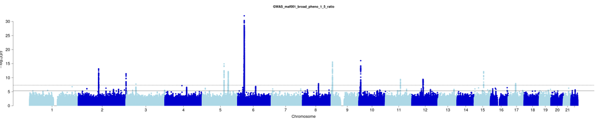

Fig 2. Manhattan plot of asthma GWAS.

[figure not shown]

Fig 3. Output of power calculation.

[figure not shown]

Fig 4. Zoom in power/effect allele frequency (eaf).

LDSC regression intercept for the GWAS was 1.02 suggesting little systematic bias due to population stratification (Fig 5). Since LDSC < 1.05, no genomic correction was applied.

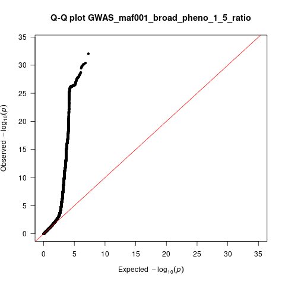

Fig 5. Q-Q plot asthma GWAS.

# Conclusion

I ran a GWAS using the REGENIE software and I obtained genome-wide significant SNPs which will be further analysed for sentinel selection, conditional analysis and several post-GWAS analyses (‘GWAS/Sentinel and Conditional analysis’; ‘Post -GWAS’).

# References

1. Mbatchou J., Barnard L., Backman J. et al. Computationally efficient whole-genome regression for quantitative and binary traits. Nat Genet 53, 1097–1103 (2021). https://doi.org/10.1038/s41588-021-00870-7
2. Chang C. et al, Second-generation PLINK: rising to the challenge of larger and richer datasets, GigaScience, Volume 4, Issue 1, December 2015, s13742–015–0047–8. https://doi.org/10.1186/s13742-015-0047-8
3. Johnson, J.L. & Abecasis, G.R. GAS Power Calculator: web-based power calculator for genetic association studies. bioRxiv, 164343 (2017).
4. Asthma, G.I.f. Global Strategy for Asthma Management and Prevention. (2022).
5. Hakonarson, H. et al. Allelic frequencies and patterns of single-nucleotide polymorphisms in candidate genes for asthma and atopy in Iceland.
6. Kuruvilla, M.E., Vanijcharoenkarn, K., Shih, J.A. & Lee, F.E. Epidemiology and risk factors for asthma.
7. Auton, A. et al. A global reference for human genetic variation. Nature 526, 68-74 (2015).